# Exercise10

## Exercise 10

[Graded] Researchers measured the yield of 5 crop species treated with 4 fertilizers. You find the measurements in the file fertilizer.dat on ILIAS.

1. Read in the data set and draw an interaction plot. R hint: since the factor levels are not encoded as strings, you first have to explicitely convert the variables CropSpecies and Fertilizer to factors.

```r
library(car)
```

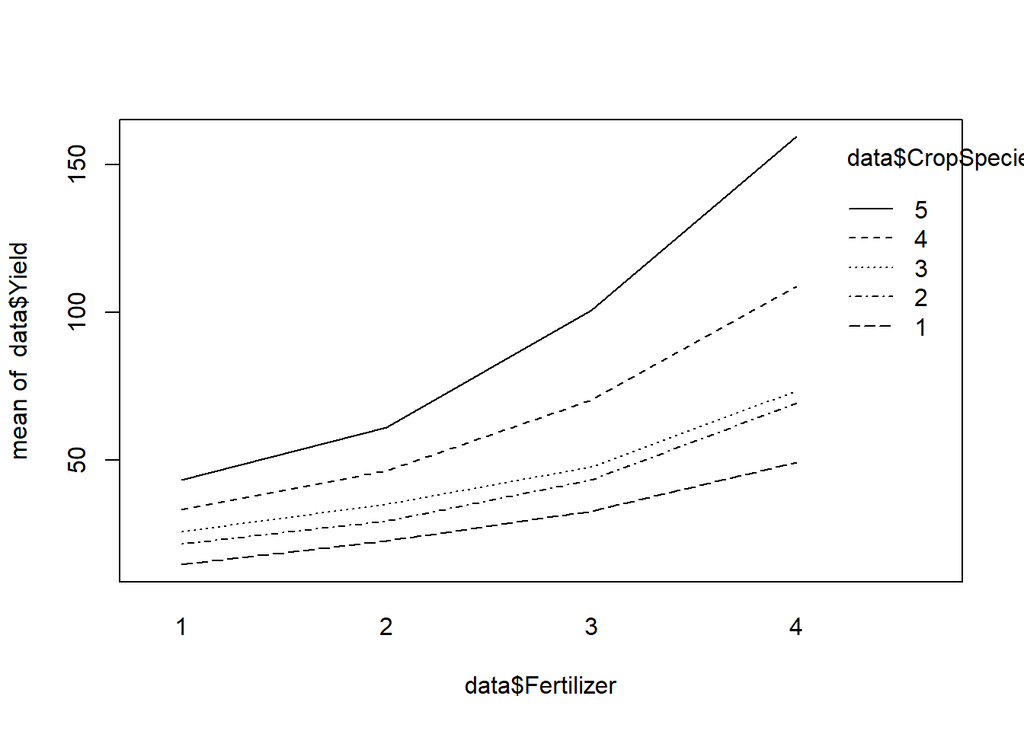

```r
data <- read.table("fertilizer.dat", header=TRUE)
data$Fertilizer <- as.factor(data$Fertilizer)
data$CropSpecies <- as.factor(data$CropSpecies)

interaction.plot(data$Fertilizer, data$CropSpecies, data$Yield)
```

2. Fit an ANOVA model without interaction to the data set. Analyse the residuals. Does the model fit well? If not, can you think of a transformation that could make the fit better?

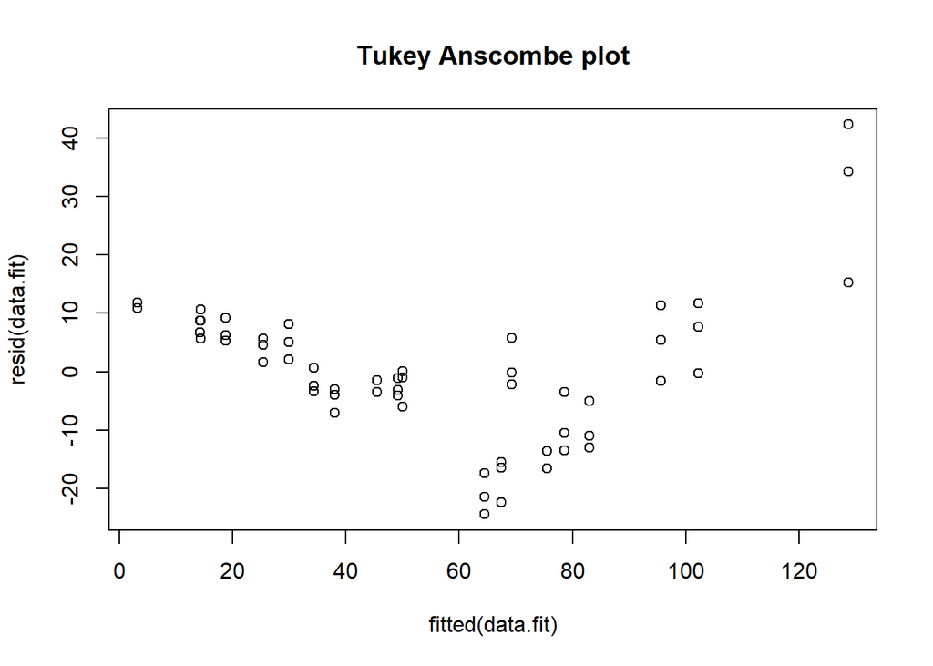

```r
data.fit <- lm(Yield ~ Fertilizer + CropSpecies, data = data)
plot(fitted(data.fit), resid(data.fit), main = "Tukey Anscombe plot")
```

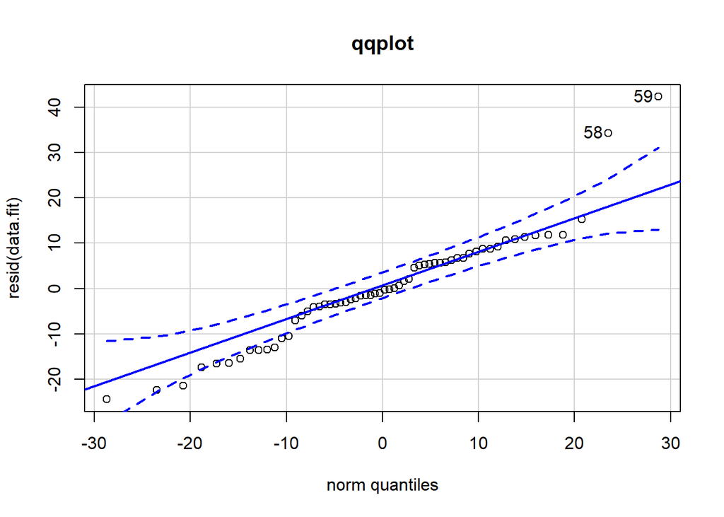

```
## [1] 59 58
```

```r
qqPlot(resid(data.fit), dist = "norm", mean = mean(resid(data.fit)), sd = sd(resid(data.fit)), main = "qqplot")
```

The two plots demonstrate a poor fit. In the Tukey Anscombe plot standard deviation increases with increasing the response variable, while the qqPlot is right skewed. This indicates that we should try a log transform.

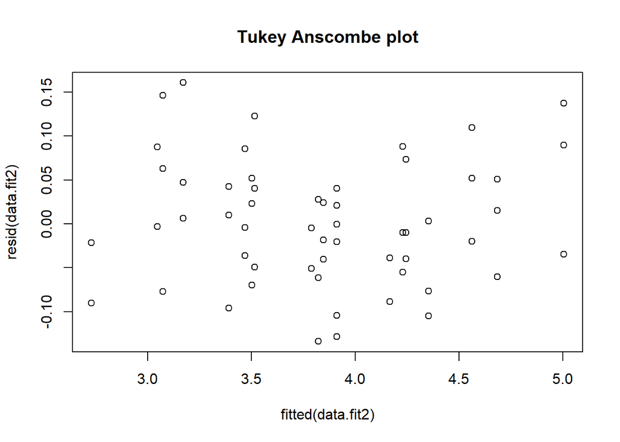

```r
data.fit2 <- lm(log(Yield) ~ Fertilizer + CropSpecies, data = data)
plot(fitted(data.fit2), resid(data.fit2), main = "Tukey Anscombe plot")
```

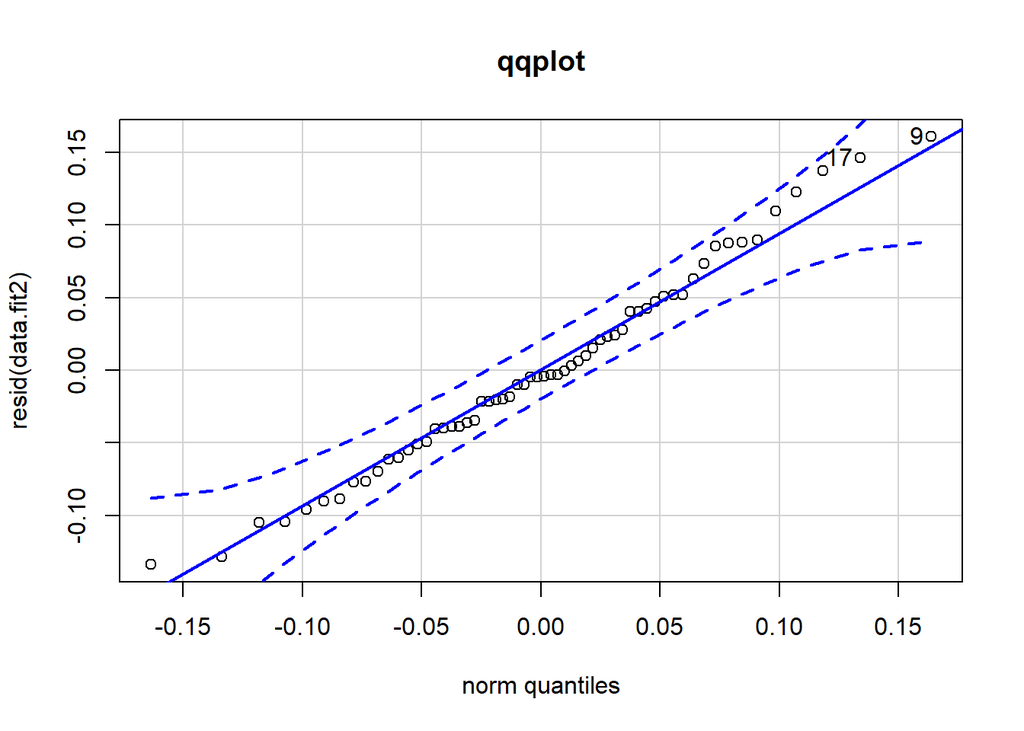

```
## [1]  9 17
```

```r
qqPlot(resid(data.fit2), dist = "norm", mean = mean(resid(data.fit2)), sd = sd(resid(data.fit2)), main = "qqplot")
```

It looks much better!

3. Add an interaction term to the model from task b). Is there a significant interaction?

```r
data.fit3 <- lm(log(Yield) ~ Fertilizer*CropSpecies, data = data)

#Note: if we try to compare with the first model, R will show an error because we need to have the log() in both.
anova(data.fit2, data.fit3)
```

```
## Analysis of Variance Table
##
## Model 1: log(Yield) ~ Fertilizer + CropSpecies
## Model 2: log(Yield) ~ Fertilizer * CropSpecies
##   Res.Df     RSS Df Sum of Sq      F Pr(>F)
## 1     52 0.27539
## 2     40 0.18253 12   0.09286 1.6958 0.1045
```

Value of the F statistic is not within the range of rejection, hence the interaction is not significant.

4. Beginning from the model from task c), perform a model selection by remove non-significant terms. In which order do you have to test the terms? With which model do you end up?

As we saw in point c, the model with the interaction term is not significant. So, we can already remove that and start again with the following model:

```r
data.fit2 <- lm(log(Yield) ~ Fertilizer + CropSpecies, data = data)
```

Next we need to check the significance of Fertilizer and CropSpecies:

```r
data.fitFertilizer <- lm(log(Yield) ~ Fertilizer, data = data)
summary(data.fitFertilizer)
```

```
##
## Call:
## lm(formula = log(Yield) ~ Fertilizer, data = data)
##
## Residuals:
##      Min       1Q   Median       3Q      Max
## -0.63000 -0.22739 -0.08185  0.27938  0.70501
##
## Coefficients:
##             Estimate Std. Error t value Pr(>|t|)
## (Intercept)   3.2550     0.1023  31.809  < 2e-16 ***
## Fertilizer2   0.3436     0.1447   2.374    0.021 *
## Fertilizer3   0.7408     0.1447   5.119 3.90e-06 ***
## Fertilizer4   1.1817     0.1447   8.166 4.13e-11 ***
## ---
## Signif. codes:  0 '***' 0.001 '**' 0.01 '*' 0.05 '.' 0.1 ' ' 1
##
## Residual standard error: 0.3963 on 56 degrees of freedom
## Multiple R-squared:  0.5707, Adjusted R-squared:  0.5477
## F-statistic: 24.81 on 3 and 56 DF,  p-value: 2.417e-10
```

```r
data.fitCropSpecies <- lm(log(Yield) ~ CropSpecies, data = data)
summary(data.fitCropSpecies)
```

```
##
## Call:
## lm(formula = log(Yield) ~ CropSpecies, data = data)
##
## Residuals:
##      Min       1Q   Median       3Q      Max
## -0.70016 -0.34042 -0.01546  0.34043  0.75262
##
## Coefficients:
##              Estimate Std. Error t value Pr(>|t|)
## (Intercept)    3.2958     0.1347  24.476  < 2e-16 ***
## CropSpecies2   0.3186     0.1904   1.673 0.100020
## CropSpecies3   0.4423     0.1904   2.323 0.023925 *
## CropSpecies4   0.7742     0.1904   4.065 0.000154 ***
## CropSpecies5   1.0932     0.1904   5.741  4.2e-07 ***
## ---
## Signif. codes:  0 '***' 0.001 '**' 0.01 '*' 0.05 '.' 0.1 ' ' 1
##
## Residual standard error: 0.4665 on 55 degrees of freedom
## Multiple R-squared:  0.4159, Adjusted R-squared:  0.3734
## F-statistic:  9.79 on 4 and 55 DF,  p-value: 4.716e-06
```

From this we conclude that both variables are significant. Therefore, our best model is: log(Yield) ~ Fertilizer + CropSpecies